# Generalized Linear Model

## Fitting the GLM Model

We fit a GLM to the data using the `glm` function in R.

```r
glm_model <- glm(y ~ x, family = binomial(link = "logit"), data = data)
x.pred <- seq(0, 1, length.out = 300)
y.pred <- predict(glm_model, newdata = data.frame(x = x.pred), type = 'response')
y.pred2 <- ifelse(y.pred > 0.5, 1, 0)

# Summary of the model
summary(glm_model)
```

```
##
## Call:
## glm(formula = y ~ x, family = binomial(link = "logit"), data = data)
##
## Coefficients:
##             Estimate Std. Error z value Pr(>|z|)
## (Intercept)  -6.3255     0.7577  -8.348   <2e-16 ***
## x            12.6001     1.4553   8.658   <2e-16 ***
## ---
## Signif. codes:  0 '***' 0.001 '**' 0.01 '*' 0.05 '.' 0.1 ' ' 1
##
## (Dispersion parameter for binomial family taken to be 1)
##
##     Null deviance: 413.97  on 299  degrees of freedom
## Residual deviance: 153.11  on 298  degrees of freedom
## AIC: 157.11
##
## Number of Fisher Scoring iterations: 6
```

```r
glm_model$coefficients
```

```
## (Intercept)           x
##   -6.325503   12.600096
```

We create a confusion matrix to evaluate the performance of the fitted model.

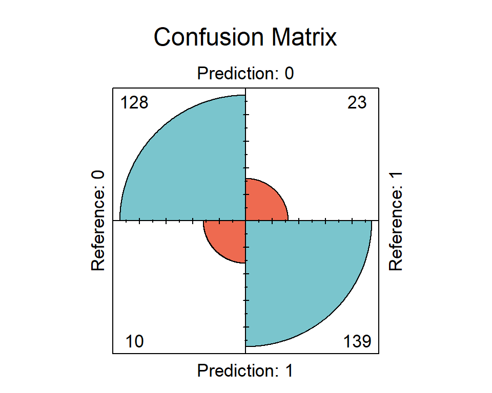

```
## $accuracy
## Accuracy
##     0.89
##
## $sensitivity
## Sensitivity
##   0.9275362
##
## $specificity
## Specificity
##   0.8580247
```

```r
mat.confusion <- function(predictions, actual_values, main = NULL) {
  cm <- confusionMatrix(predictions, actual_values)

  accuracy <- cm$overall["Accuracy"]
  sensitivity <- cm$byClass["Sensitivity"]
  specificity <- cm$byClass["Specificity"]

  fourfoldplot(cm$table, color = c("coral2", "cadetblue3"), conf.level = 0, main = main)
  return(list(accuracy = accuracy, sensitivity = sensitivity, specificity = specificity))
}

predictions <- factor(y.pred2, levels = c(0, 1))
actual_values <- factor(y, levels = c(0, 1))
mat.confusion(predictions = predictions, actual_values = actual_values, main = 'Confusion Matrix')
```

We visualize the fitted GLM along with the observed data and the predicted probabilities.

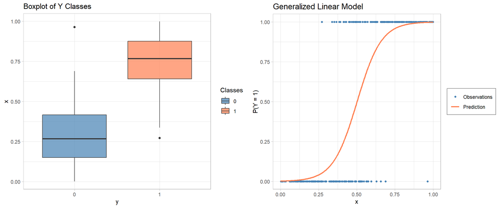

```r
data.model <- data.frame(x, y, prob, x.pred, y.pred)
plot2 <- ggplot(data = data.model) +
  geom_point(aes(x = x, y = y, color = "Observations"), shape = 20, size = 2) +
  geom_line(aes(x = x.pred, y = y.pred, color = "Prediction"), linewidth = 1) +
  scale_color_manual(values = c("Observations" = "steelblue",
                                "Prediction" = "coral")) +
  labs(title = "Generalized Linear Model",
       x = "x",
       y = "P(Y = 1)",
       color = NULL) +
  theme_light() +
  theme(plot.title = element_text(size = 14),
        legend.position.inside = c(0.2, 0.8),
        legend.background = element_rect(fill = "white", colour = "gray50"))

plot <- grid.arrange(plot1, plot2, nrow = 1, ncol = 2)
```

Finally, we perform a residual analysis to assess the model fit.

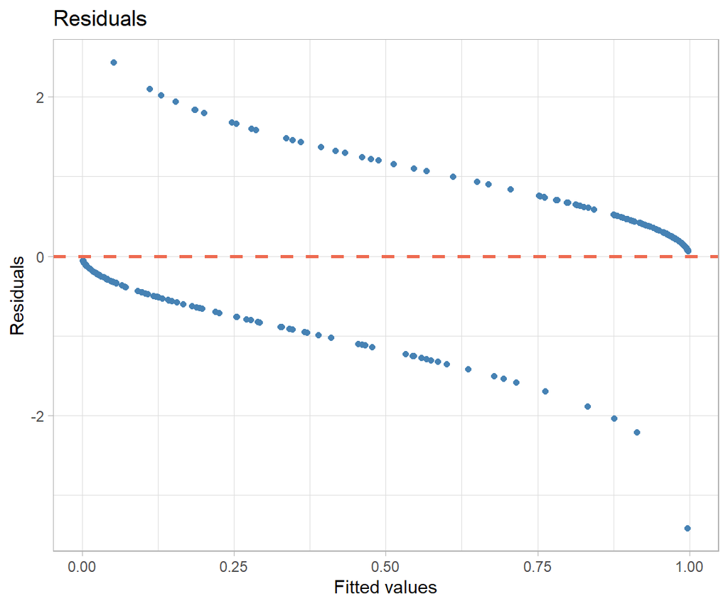

```r
residuals <- resid(glm_model)
ggplot(data, aes(x = fitted(glm_model), y = residuals)) +
  geom_point(color = "steelblue") +
  geom_hline(yintercept = 0, linetype = "dashed", color = "coral2", linewidth = 1) +
  labs(title = "Residuals",
       x = "Fitted values",
       y = "Residuals",
       color = NULL) +
  theme_light()
```

## Manual Parameter Estimation

We manually estimate the parameters of the logistic regression model using the iterative reweighted least squares (IRLS) method.

```r
sigmoid <- function(x) { 1 / (1 + exp(-x)) }

b.i <- c(-5, 10)
X <- cbind(rep(1, n), x)
for (i in 1:100) {
  nu.i <- X %*% b.i
  s <- sigmoid(nu.i)
  W.i <- diag(as.numeric(s * (1 - s)))
  z.i <- nu.i + (y - s) * (1 / (s * (1 - s)))
  b.i <- solve(t(X) %*% W.i %*% X) %*% t(X) %*% W.i %*% z.i
}
print(b.i)
```

```
##        [,1]
##   -6.325503
## x 12.600096
```